# 17 - PCA and nMDS

Francisco E. Fonturbel

04/January/2023

## Dealing with multiple variables at once

Dealing with biodiversity data is somewhat different than dealing with the usual stuff that we are (now) used to. Besides formal tests, there are some multivariate tests that allow us to conduct a visual exploration of our data, instead than testing an hypothesis.

```r
library(dplyr)
library(ggplot2)
library(ggsci)
library(ggpubr)
library(vegan)
library(ade4)
library(ecodist)
library("factoextra")

#Loading work data
data = read.csv("data/17_monito_hab.csv",
                   header=TRUE,
                   sep=",")
attach(data)
head(data)
```

```
##   Trap grid Oc.1 Oc.2 Oc.3 Oc.t     Cover Moss.Cef sp.trap  a.luma.p drimys.p
## 1 1Y_1   G1    0    0    0    0 0.9168000        3  Citron 2037.1785        0
## 2 2Y_1   G1    0    0    0    0 0.8726000        3  A.luma 1527.8839        0
## 3 3Y_1   G1    0    0    0    0 0.9298000        2  A.luma 1018.5893        0
## 4 4Y_1   G1    0    0    0    0 0.9116000        3  A.luma  509.2946        0
## 5 5Y_1   G1    0    0    0    0 0.7998000        1   Embot    0.0000        0
## 6 1Z_1   G1    0    0    0    0 0.8786667        2   Eucry 1527.8839        0
##   l.apicul.p mayte.p rhaph.p aristo.p tristerix.p ch.quila.p grise.p  p.total
## 1          0       0       0        0      0.0000          0       0 4074.357
## 2          0       0       0        0      0.0000          0       0 2546.473
## 3          0       0       0        0      0.0000          0       0 3055.768
## 4          0       0       0        0    509.2946          0       0 2037.179
## 5          0       0       0        0      0.0000          0       0 2037.179
## 6          0       0       0        0      0.0000          0       0 4074.357
##   fruits.eaten.1 fruits.poten.1 fruits.total.1 fruits.eaten.2 fruits.poten.2
```

[output cut: 27 more lines]

Today we will use some data of Gonzalez-Ancin et al. 2022 as a working example. This dataset contains habitat structure variables of three forests stands in which we captured *Dromiciops gliroides* nearby the Pucatrihue bay.

## Analysis of Principal Components (PCA)

The Analysis of Principal Components reduces many variables to a few dimensions (usually two or three) calllen “principal components” that are orthologous (i.e., independent) from each other. Principal components are always arranged from the one that explains most of the data variance to the least. Each principal component has an associated eigenvector that is a proxy of its importance, usually eigenvalues >1 are meaningful.

```
## Importance of components:
##                           PC1    PC2    PC3     PC4     PC5
## Standard deviation     1.5908 0.9922 0.9481 0.66355 0.38151
## Proportion of Variance 0.5061 0.1969 0.1798 0.08806 0.02911
## Cumulative Proportion  0.5061 0.7031 0.8828 0.97089 1.00000
```

```
## eigen() decomposition
## $values
## [1] 2.5307579 0.9845427 0.8988523 0.4402939 0.1455533
##
## $vectors
##           [,1]        [,2]       [,3]       [,4]        [,5]
## [1,] 0.1611506  0.90630655 -0.3571371  0.1572079 -0.01943477
## [2,] 0.2634581  0.30106964  0.9018504  0.0230765 -0.16149354
## [3,] 0.5159243 -0.01263037 -0.1543700 -0.8267771 -0.16208660
## [4,] 0.5400477 -0.26845551 -0.1878448  0.4934008 -0.59795492
## [5,] 0.5888896 -0.12544967  0.0017685  0.2185140  0.76793227
```

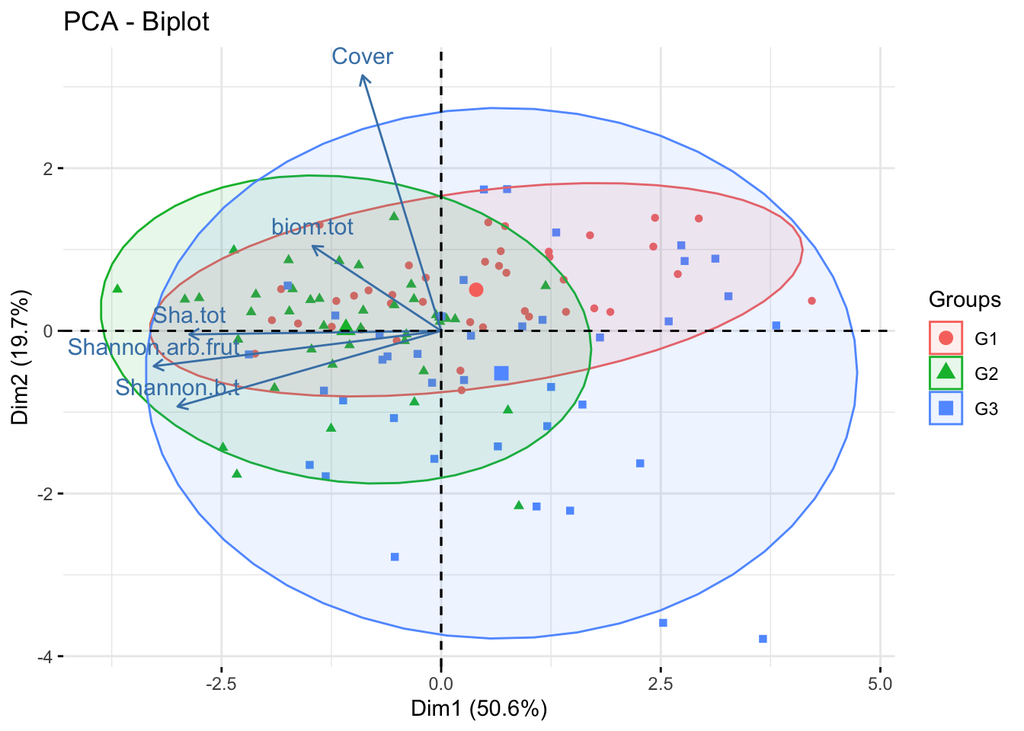

The resulting plot shows each forest stand (G1, G2, and G3) and the arrows represent the variables and their relative contribution to the first to principal components (PC1 and PC2).

Some people use this visual interpretation to group variables, for example those with larger contributions to PC1 in one group and those with larger contributions to PC2 in other group, and name the groups according to the type of variables involved (it requires some imagination sometimes). Also, we can use the PCA scores as surrogate variables to simplify our analyses in case we don’t want to include that many variables in one model, for example.

## Non-metric multidimensional scaling (nMDS)

The non-metric multidimensional scaling works in a similar philosophy than `PCA`, grouping variables using an ordination algorithm. Usually we apply `nMDS` together with `ANOSIM` to visualize species composition differences (but it can be used with any kind of variables that have at least two discrete groups). As ANOSIM, nMDS requires replicated data (at least three replicates per group).

Let’s remember our last lesson and conduct an `ANOSIM` test to compare plant species composition among the same three forest stands above.

```r
plants = read.csv("data/17_data_plants.csv",
                   header=TRUE,
                   sep=",")

plant.dt<-plants[,2:24]
plantdist<-vegdist(plant.dt)

plant.anosim<-anosim(plantdist, plants$grid, permutations = 999, distance = "bray")
summary(plant.anosim)
```

```
##
## Call:
## anosim(x = plantdist, grouping = plants$grid, permutations = 999,      distance = "bray")
## Dissimilarity: bray
##
## ANOSIM statistic R: 0.3742
##       Significance: 0.001
##
## Permutation: free
## Number of permutations: 999
##
## Upper quantiles of permutations (null model):
##    90%    95%  97.5%    99%
## 0.0147 0.0208 0.0251 0.0331
##
## Dissimilarity ranks between and within classes:
##          0%  25%    50%    75%   100%    N
## Between 2.5 2516 4193.0 5691.5 6976.5 4800
## G1      2.5  946 2516.0 4341.0 6976.5  780
## G2      1.0  897 2106.5 3767.5 6976.5  780
## G3      4.0  946 2516.0 4095.5 6976.5  780
```

Our ANOSIM results show that species composition diffents among forest stands, but how can we represent it in a nice plot?

```r
plant.mds<-metaMDS(plantdist, distance = "bray")
```

```
## *** No convergence -- monoMDS stopping criteria:
##     20: stress ratio > sratmax
```

```r
plant.mds
```

```
##
## Call:
## metaMDS(comm = plantdist, distance = "bray")
##
## global Multidimensional Scaling using monoMDS
##
## Data:     plantdist
## Distance: bray
##
## Dimensions: 2
## Stress:     0.2509634
## Stress type 1, weak ties
## No convergent solutions - best solution after 20 tries
## Scaling: centring, PC rotation
## Species: scores missing
```

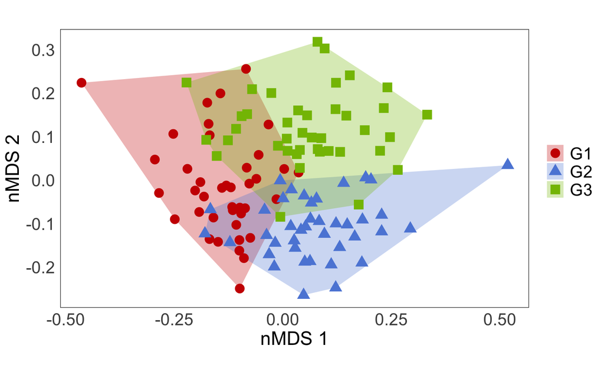

```r
plant.scores<-as.data.frame(scores(plant.mds))
plant.scores$site<-rownames(plant.scores)
plant.scores$grid<-plants$grid

grp.G1 <- plant.scores[plant.scores$grid == "G1", ][chull(plant.scores[plant.scores$grid ==
    "G1", c("NMDS1", "NMDS2")]), ]  # hull values for Native habitat
grp.G2 <- plant.scores[plant.scores$grid == "G2", ][chull(plant.scores[plant.scores$grid ==
    "G2", c("NMDS1", "NMDS2")]), ]  # hull values for Secondary habitat
grp.G3 <- plant.scores[plant.scores$grid == "G3", ][chull(plant.scores[plant.scores$grid ==
    "G3", c("NMDS1", "NMDS2")]), ]  # hull values for Logged habitat

hull.plant <- rbind(grp.G1, grp.G2, grp.G3)  #combine groups

plant.nmds.plot<-ggplot() +
  geom_polygon(data=hull.plant,aes(x=NMDS1,y=NMDS2,fill=grid,group=grid),alpha=0.30) + # add the convex hulls
  geom_point(data=plant.scores,aes(x=NMDS1,y=NMDS2,shape=grid,colour=grid),size=4) + # add the point markers
  coord_equal() +
  scale_fill_startrek() +
  scale_color_startrek() +
  theme_bw() +
  labs(x="nMDS 1", y="nMDS 2") +
  theme(axis.text.x = element_text(size = 16),  # remove x-axis text
        axis.text.y = element_text(size = 16), # remove y-axis text
        axis.ticks = element_blank(),  # remove axis ticks
        axis.title.x = element_text(size=18), # remove x-axis labels
        axis.title.y = element_text(size=18), # remove y-axis labels
        panel.background = element_blank(),
        panel.grid.major = element_blank(),  #remove major-grid labels
        panel.grid.minor = element_blank(),  #remove minor-grid labels
        plot.background = element_blank(),
        legend.title = element_blank(),
        legend.text = element_text(size = 16))
plant.nmds.plot
```

```r
#Obtaining nMDS stress
plant.mds$stress
```

```
## [1] 0.2509634
```

Well, this very cute plot is an abstract representation of species composition differences. Each forest stand is represented by one polygon (I used different colors on purpose), the larger overlap among polygons the more similar species composition is, so when polygons do not overlap we have different species compositions. Below the plot we present a stress value. In nMDS, stress represents how well the ordination explains our data. Stress values range from to 0 to 1, being values ≤0.3 acceptable, ≤ 0.2 are good, and ≤0.1 are very good. Ordinations with stress values between 0.3 and 0.5 are doubtful, and those >0.5 are simply useless.

## Final thoughts

PCA and nMDS are powerful visual tools to complement our formal hypothesis-testing analysis but also to explore our dataset in advance and see (in a nice graph) how our data behaves and help deciding which analysis approach will be used.

Licensing Creative Commons License

Licensed under a Creative Commons Attribution-ShareAlike 4.0 International License.  
2022 - Francisco E. Fontúrbel